# Nitinat escapement 2023 (PRELIM)

## 1.4 Preliminary escapement estimate (AUC)

Table: Raw chinook counts

| date | type | section | adults_live | adults_spawning | adults_holding | dead_adults | EXPANDED_LIVE_ADULTS | jacks_live | jacks_spawning | jacks_holding | dead_jacks |
| --- | --- | --- | --- | --- | --- | --- | --- | --- | --- | --- | --- |
| 2023-08-28 | swim | lower | 13 | 0 | 13 | 0 | 14 | 3 | 0 | 3 | 0 |
| 2023-09-07 | swim | lower | 213 | 0 | 213 | 0 | 225 | 26 | 0 | 26 | 0 |
| 2023-09-21 | swim | lower | 2004 | 0 | 2004 | 1 | 2358 | 35 | 0 | 35 | 0 |
| 2023-09-29 | swim | lower | 13995 | 100 | 13895 | 0 | 16122 | 0 | NA | NA | 0 |
| 2023-09-29 | swim | upper | 1548 | 52 | 1496 | 0 | 2284 | 91 | NA | NA | 0 |
| 2023-10-05 | swim | lower | 4288 | 0 | 4288 | 88 | 5255 | 18 | 0 | 18 | 0 |
| 2023-10-05 | swim | upper | 2201 | 940 | 1261 | 1 | 2452 | 1 | 0 | 1 | 0 |
| 2023-10-12 | heli | full (heli) | 9480 | 0 | 9480 | 0 | 9480 | 0 | 0 | 0 | 0 |
| 2023-10-26 | swim | lower | 31 | 0 | 31 | 199 | 36 | 0 | 0 | 0 | 0 |
| 2023-10-26 | swim | upper | 16 | 0 | 16 | 32 | 18 | 0 | 0 | 0 | 0 |
| 2023-11-09 | swim | lower | 0 | 0 | 0 | 7 | 0 | 0 | 0 | 0 | 0 |

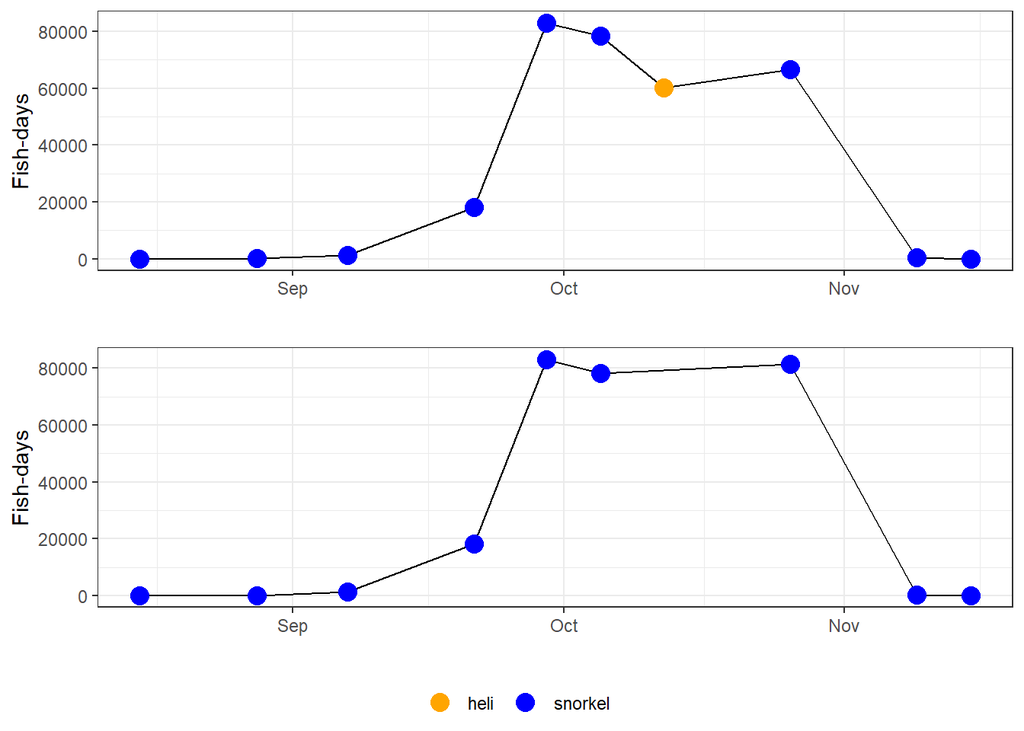

Figure: AUC curves with heli (top) and without heli (bottom) survey.

Table: AUC math (copy of Z:/WCVI/ESCAPEMENT/Data/2023/SILs/Area 21-22/Nitinat River/A22_Nitinat_River_2023)

| method | survey_date | date_range_start | date_range_end | numDays | raw_adult_live | expanded adult | type |
| --- | --- | --- | --- | --- | --- | --- | --- |
| with heli | 2023-08-15 | NA | NA | NA | 0 | 0.00000 | snorkel |
| with heli | 2023-08-28 | 2023-08-15 | 2023-08-28 | 13 | 13 | 88.94737 | snorkel |
| with heli | 2023-09-07 | 2023-08-28 | 2023-09-07 | 10 | 213 | 1191.33127 | snorkel |
| with heli | 2023-09-21 | 2023-09-07 | 2023-09-21 | 14 | 2004 | 18076.69032 | snorkel |
| with heli | 2023-09-29 | 2023-09-21 | 2023-09-29 | 8 | 15543 | 83057.92398 | snorkel |
| with heli | 2023-10-05 | 2023-09-29 | 2023-10-05 | 6 | 6489 | 78340.66803 | snorkel |
| with heli | 2023-10-12 | 2023-10-05 | 2023-10-12 | 7 | 9480 | 60154.07056 | heli |
| with heli | 2023-10-26 | 2023-10-12 | 2023-10-26 | 14 | 47 | 66732.39121 | snorkel |
| with heli | 2023-11-09 | 2023-10-26 | 2023-11-09 | 14 | 0 | 372.39121 | snorkel |
| with heli | 2023-11-15 | 2023-11-09 | 2023-11-15 | 6 | 0 | 0.00000 | snorkel |
| without heli | 2023-08-15 | NA | NA | NA | 0 | 0.00000 | snorkel |
| without heli | 2023-08-28 | 2023-08-15 | 2023-08-28 | 13 | 13 | 88.94737 | snorkel |
| without heli | 2023-09-07 | 2023-08-28 | 2023-09-07 | 10 | 213 | 1191.33127 | snorkel |
| without heli | 2023-09-21 | 2023-09-07 | 2023-09-21 | 14 | 2004 | 18076.69032 | snorkel |
| without heli | 2023-09-29 | 2023-09-21 | 2023-09-29 | 8 | 15543 | 83057.92398 | snorkel |
| without heli | 2023-10-05 | 2023-09-29 | 2023-10-05 | 6 | 6489 | 78340.66803 | snorkel |
| without heli | 2023-10-26 | 2023-10-05 | 2023-10-26 | 21 | 47 | 81480.79850 | snorkel |
| without heli | 2023-11-09 | 2023-10-26 | 2023-11-09 | 14 | 0 | 372.39121 | snorkel |
| without heli | 2023-11-15 | 2023-11-09 | 2023-11-15 | 6 | 0 | 0.00000 | snorkel |

Table: Escapement estimates with/without helicopter survey for each survey life value.

| method | Rank | SL | Estimate | Est_without_swimins |
| --- | --- | --- | --- | --- |
| with heli | Low Value | 15 | 20534 | 13688 |
| with heli | Middle Value | 20 | 15401 | 8555 |
| with heli | High Value | 25 | 12321 | 5475 |
| without heli | Low Value | 15 | 17507 | 10661 |
| without heli | Middle Value | 20 | 13130 | 6284 |
| without heli | High Value | 25 | 10504 | 3658 |

For 2023 estimate we went with SL=15 for three reasons: First, there were a lot more swim-ins than usual this year, which was attributed to the COVID releases leaving the hatchery directly rather than being reared in the lake pen. Fish homing to the hatchery may have had more directed migration and therefore not stayed in the system long. Second, the higher estimate from the shorter SL resulted in an estimate that was high enough to cover the raw peak live count of ~15k, but once removing the 6846 swim-ins still resulted in a reasonable estimate that agreed with what the hatchery observed. Third, there may have been a slight delay in entry as the water was low for the early season and rains were a bit later than usual (though not as late as 2022).